# Regressions

Johanna Mehler

2024-04-15

# 1 Data preparation

## 1.1 Libraries and read in data

```r
library(tidyverse)
library(here)
library(table1)
```

```r
library(ggplot2)
library(lmtest)
data <- read_csv(here("data", "data_combined.csv"),
                 col_types = cols(
                   academic_status = col_factor(levels = c("academic", "non-academic")),
                   educ_cat = col_factor(levels = c("Low", "Intermediate", "High")),
                   gender = col_factor(levels = c("Male", "Female")),
                   age_cat = col_factor(levels = c("18-29", "30-49", "50-69", "70+")),
                   polinterest = col_factor(levels = c("1", "2", "3", "4")),
                   polinterest_cat_3 = col_factor(levels = c("Low", "Intermediate", "High")),
                   minority = col_factor(levels = c("0", "1")),
                   minority_cat = col_factor(levels = c("Non-minority", "Minority")),
                   empathy_pc_cat = col_factor(levels = c("Less empathetic", "More empathetic")),
                   exp_hate_speech_cat = col_factor(levels = c("Less experience", "More experience")),
                   exp_hostile_engagement_cat = col_factor(levels = c("Less experience", "More experience")),
                   cluster = col_factor(levels = c("A", "B", "C", "D"))
                 ))

# filter out NA's in academic status and extreme outliers
data <- data %>% filter(!is.na(educ_cat), !is.na(academic_status), text_length < 1000, readability_score < 40)

# check data types and scales
data %>% summary()
```

```
##   ResponseId            academic_status         educ_cat      gender
##  Length:944         academic    :557    Low         :170   Male  :619
##  Class :character   non-academic:387    Intermediate:217   Female:312
##  Mode  :character                       High        :557   NA's  : 13
##
##
##
##
##       age            age10        age_cat    polinterest    polinterest_cat_3
##  Min.   :23.00   Min.   :2.300   18-29:129   1: 44       Low         :141
##  1st Qu.:35.00   1st Qu.:3.500   30-49:386   2: 97       Intermediate:383
##  Median :47.00   Median :4.700   50-69:369   3:383       High        :420
##  Mean   :47.07   Mean   :4.707   70+  : 60   4:420
##  3rd Qu.:58.00   3rd Qu.:5.800
##  Max.   :88.00   Max.   :8.800
##
##    empathy_pc        exp_hate_speech exp_hostile_engagement minority
##  Min.   :-2.107494   Min.   :1.000   Min.   :1.000          0   :626
##  1st Qu.:-0.973255   1st Qu.:2.600   1st Qu.:2.000          1   :316
##  Median :-0.416570   Median :3.000   Median :2.333          NA's:  2
##  Mean   :-0.009759   Mean   :3.024   Mean   :2.352
##  3rd Qu.: 0.716204   3rd Qu.:3.400   3rd Qu.:3.000
##  Max.   : 4.650343   Max.   :4.000   Max.   :4.000
##  NA's   :4                           NA's   :1
##        minority_cat         empathy_pc_cat      exp_hate_speech_cat
##  Non-minority:626   Less empathetic:498    Less experience:508
##  Minority    :316   More empathetic:442    More experience:436
##  NA's        :  2   NA's           :  4
##
##
##
##
##    exp_hostile_engagement_cat text_length_abs   text_length
##  Less experience:348          Min.   :   1.0   Min.   : 0.000
##  More experience:595          1st Qu.:  57.0   1st Qu.: 5.833
##  NA's           :  1          Median :  96.0   Median : 6.585
##                               Mean   : 136.1   Mean   : 6.535
##                               3rd Qu.: 162.0   3rd Qu.: 7.340
##                               Max.   :1271.0   Max.   :10.312
##
##  readability_score cluster   leftright      leftright_pred_score
##  Min.   :-7.940    A:278   Min.   : 1.000   Min.   :3.937
##  1st Qu.: 7.992    B:304   1st Qu.: 5.000   1st Qu.:7.088
##  Median :11.483    C:176   Median : 6.000   Median :8.215
##  Mean   :11.546    D:186   Mean   : 6.227   Mean   :8.019
##  3rd Qu.:14.655            3rd Qu.: 8.000   3rd Qu.:9.234
##  Max.   :32.253            Max.   :11.000   Max.   :9.997
##                                             NA's   :668
##  hate_definition
##  Length:944
##  Class :character
##  Mode  :character
##
##
##
##
```

```r
# print table
table1(~ academic_status + educ_cat + gender + age_cat + polinterest + minority_cat + empathy_pc_cat + exp_hate_speech_cat + exp_hostile_engagement_cat + cluster, data = data)
```

|  | Overall (N=944) |
| --- | --- |
| academic_status |  |
| academic | 557 (59.0%) |
| non-academic | 387 (41.0%) |
| educ_cat |  |
| Low | 170 (18.0%) |
| Intermediate | 217 (23.0%) |
| High | 557 (59.0%) |
| gender |  |
| Male | 619 (65.6%) |
| Female | 312 (33.1%) |
| Missing | 13 (1.4%) |
| age_cat |  |
| 18-29 | 129 (13.7%) |
| 30-49 | 386 (40.9%) |
| 50-69 | 369 (39.1%) |
| 70+ | 60 (6.4%) |
| polinterest |  |
| 1 | 44 (4.7%) |
| 2 | 97 (10.3%) |
| 3 | 383 (40.6%) |
| 4 | 420 (44.5%) |
| minority_cat |  |
| Non-minority | 626 (66.3%) |
| Minority | 316 (33.5%) |
| Missing | 2 (0.2%) |
| empathy_pc_cat |  |
| Less empathetic | 498 (52.8%) |
| More empathetic | 442 (46.8%) |
| Missing | 4 (0.4%) |
| exp_hate_speech_cat |  |
| Less experience | 508 (53.8%) |
| More experience | 436 (46.2%) |
| exp_hostile_engagement_cat |  |
| Less experience | 348 (36.9%) |
| More experience | 595 (63.0%) |
| Missing | 1 (0.1%) |
| cluster |  |
| A | 278 (29.4%) |
| B | 304 (32.2%) |
| C | 176 (18.6%) |
| D | 186 (19.7%) |

### 1.1.1 Compare with whole dataset (19,000+)

```r
# compare with whole dataset
data_all <- read_csv(here("data/data_clean.csv"))
# print table
table1(~ educ_cat + gender + age_cat + polinterest + minority_cat, data = data_all)
```

|  | Overall (N=19172) |
| --- | --- |
| educ_cat |  |
| High | 10773 (56.2%) |
| Intermediate | 3967 (20.7%) |
| Low | 4161 (21.7%) |
| Missing | 271 (1.4%) |
| gender |  |
| Female | 6479 (33.8%) |
| Male | 12312 (64.2%) |
| Other | 381 (2.0%) |
| age_cat |  |
| 18-29 | 4689 (24.5%) |
| 30-49 | 6932 (36.2%) |
| 50-69 | 6400 (33.4%) |
| 70+ | 1104 (5.8%) |
| Missing | 47 (0.2%) |
| polinterest |  |
| Mean (SD) | 3.15 (0.875) |
| Median [Min, Max] | 3.00 [1.00, 4.00] |
| Missing | 26 (0.1%) |
| minority_cat |  |
| Minority | 6170 (32.2%) |
| Non-minority | 12872 (67.1%) |
| Missing | 130 (0.7%) |

# 2 Regressions

## 2.1 Text Length

### 2.1.1 More controls

```r
# Linear regression model with all controls
model_text_length <- lm(text_length ~ academic_status + gender + age_cat + minority_cat + polinterest_cat_3 + empathy_pc + exp_hate_speech + exp_hostile_engagement, data = data)

summary(model_text_length)
```

```
##
## Call:
## lm(formula = text_length ~ academic_status + gender + age_cat +
##     minority_cat + polinterest_cat_3 + empathy_pc + exp_hate_speech +
##     exp_hostile_engagement, data = data)
##
## Residuals:
##     Min      1Q  Median      3Q     Max
## -6.5804 -0.7137  0.0501  0.8374  3.8664
##
## Coefficients:
##                               Estimate Std. Error t value Pr(>|t|)
## (Intercept)                    5.87643    0.31069  18.914  < 2e-16 ***
## academic_statusnon-academic   -0.07073    0.09071  -0.780  0.43573
## genderFemale                  -0.02440    0.09795  -0.249  0.80335
## age_cat30-49                  -0.27683    0.13709  -2.019  0.04374 *
## age_cat50-69                  -0.17860    0.14056  -1.271  0.20416
## age_cat70+                    -0.19879    0.21539  -0.923  0.35630
## minority_catMinority           0.04763    0.09430   0.505  0.61358
## polinterest_cat_3Intermediate  0.07791    0.13660   0.570  0.56862
## polinterest_cat_3High          0.16465    0.14302   1.151  0.24992
## empathy_pc                    -0.09441    0.03478  -2.714  0.00677 **
## exp_hate_speech                0.20799    0.08990   2.314  0.02091 *
## exp_hostile_engagement         0.05677    0.07516   0.755  0.45022
## ---
## Signif. codes:  0 '***' 0.001 '**' 0.01 '*' 0.05 '.' 0.1 ' ' 1
##
## Residual standard error: 1.326 on 913 degrees of freedom
##   (19 observations deleted due to missingness)
## Multiple R-squared:  0.02799,    Adjusted R-squared:  0.01628
## F-statistic:  2.39 on 11 and 913 DF,  p-value: 0.006382
```

*Residuals Plot for Homoscedasticity and Linearity*

check if the residuals (differences between observed and predicted values) display constant variance across all levels of the predicted values (homoscedasticity) and if the relationship between the predictors and the outcome is linear.

**Homoscedasticity**: The spread of residuals should be roughly constant across all fitted values.

**Linearity**: The residuals should be randomly dispersed around the horizontal axis, without any systematic shape.

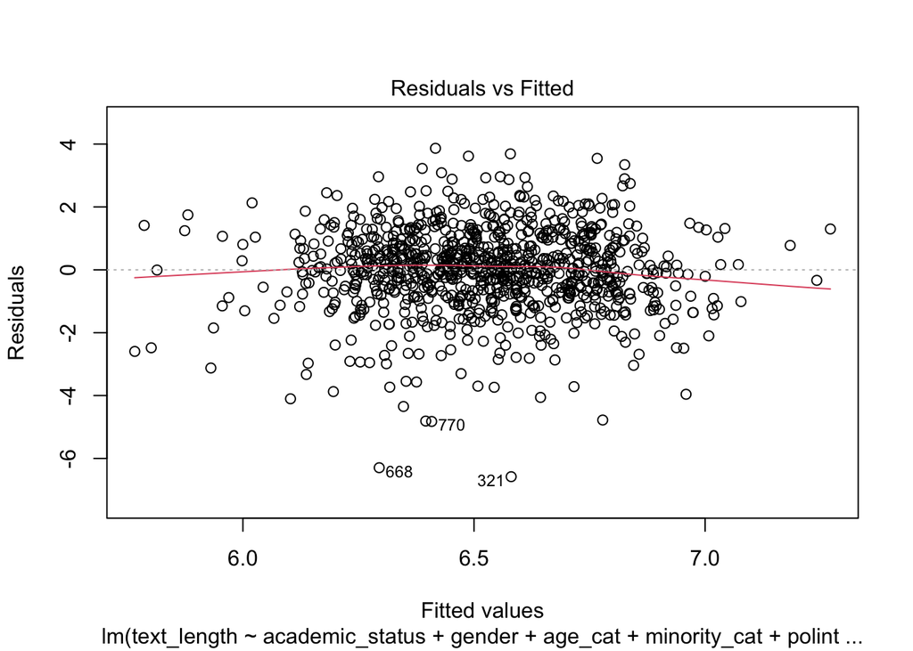

```r
# Plotting residuals vs. fitted values
plot(model_text_length, which = 1)
```

*Q-Q Plots for Normality of Residuals*

Q-Q (quantile-quantile) plot to assess whether the residuals follow a normal distribution

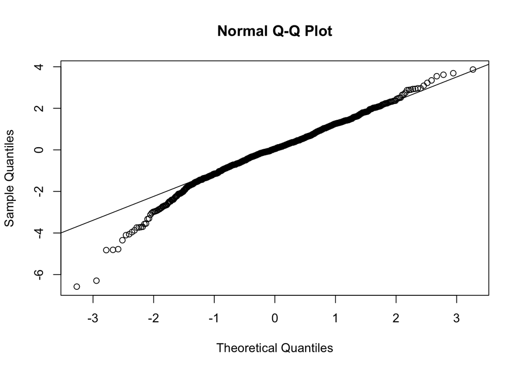

```r
# Q-Q plot
qqnorm(residuals(model_text_length))
qqline(residuals(model_text_length))
```

*Variance Inflation Factor (VIF) for Multicollinearity*

Assesses how much the variance of a coefficient is inflated due to multicollinearity in the model. VIF values above 5 or 10 indicate high multicollinearity that could be problematic.

```r
library(car)
vif(model_text_length)
```

```
##                            GVIF Df GVIF^(1/(2*Df))
## academic_status        1.046606  1        1.023038
## gender                 1.125272  1        1.060788
## age_cat                1.123885  3        1.019656
## minority_cat           1.036120  1        1.017900
## polinterest_cat_3      1.236744  2        1.054557
## empathy_pc             1.063953  1        1.031481
## exp_hate_speech        1.172333  1        1.082743
## exp_hostile_engagement 1.309381  1        1.144282
```

### 2.1.2 Less Controls

```r
# Linear regression model with less controls (assuming that they are later in the causal chain)
model_text_length <- lm(text_length ~ academic_status + gender + age_cat + minority_cat + exp_hate_speech, data = data)

summary(model_text_length)
```

```
##
## Call:
## lm(formula = text_length ~ academic_status + gender + age_cat +
##     minority_cat + exp_hate_speech, data = data)
##
## Residuals:
##     Min      1Q  Median      3Q     Max
## -6.5680 -0.7187  0.0513  0.8402  3.8279
##
## Coefficients:
##                             Estimate Std. Error t value Pr(>|t|)
## (Intercept)                  5.90856    0.28585  20.670  < 2e-16 ***
## academic_statusnon-academic -0.08049    0.08955  -0.899  0.36896
## genderFemale                -0.04527    0.09284  -0.488  0.62594
## age_cat30-49                -0.24255    0.13674  -1.774  0.07642 .
## age_cat50-69                -0.13699    0.13834  -0.990  0.32230
## age_cat70+                  -0.11938    0.21113  -0.565  0.57191
## minority_catMinority         0.04003    0.09359   0.428  0.66895
## exp_hate_speech              0.26937    0.08375   3.216  0.00134 **
## ---
## Signif. codes:  0 '***' 0.001 '**' 0.01 '*' 0.05 '.' 0.1 ' ' 1
##
## Residual standard error: 1.328 on 921 degrees of freedom
##   (15 observations deleted due to missingness)
## Multiple R-squared:  0.01643,    Adjusted R-squared:  0.00895
## F-statistic: 2.197 on 7 and 921 DF,  p-value: 0.0324
```

*Residuals Plot for Homoscedasticity and Linearity*

check if the residuals (differences between observed and predicted values) display constant variance across all levels of the predicted values (homoscedasticity) and if the relationship between the predictors and the outcome is linear.

**Homoscedasticity**: The spread of residuals should be roughly constant across all fitted values.

**Linearity**: The residuals should be randomly dispersed around the horizontal axis, without any systematic shape.

```r
# Plotting residuals vs. fitted values
plot(model_text_length, which = 1)
```

[output not shown]

*Q-Q Plots for Normality of Residuals*

Q-Q (quantile-quantile) plot to assess whether the residuals follow a normal distribution

```r
# Q-Q plot
qqnorm(residuals(model_text_length))
qqline(residuals(model_text_length))
```

[output not shown]

*Variance Inflation Factor (VIF) for Multicollinearity*

Assesses how much the variance of a coefficient is inflated due to multicollinearity in the model. VIF values above 5 or 10 indicate high multicollinearity that could be problematic.

```r
library(car)

vif(model_text_length)
```

```
##                     GVIF Df GVIF^(1/(2*Df))
## academic_status 1.020439  1        1.010168
## gender          1.012136  1        1.006050
## age_cat         1.043753  3        1.007163
## minority_cat    1.021919  1        1.010900
## exp_hate_speech 1.037361  1        1.018509
```

## 2.2 Readability

### 2.2.1 More controls

```r
# Linear regression model with all controls
model_readability <- lm(readability_score ~ academic_status + gender + age_cat + minority_cat + polinterest_cat_3 + empathy_pc + exp_hate_speech + exp_hostile_engagement, data = data)

summary(model_readability)
```

```
##
## Call:
## lm(formula = readability_score ~ academic_status + gender + age_cat +
##     minority_cat + polinterest_cat_3 + empathy_pc + exp_hate_speech +
##     exp_hostile_engagement, data = data)
##
## Residuals:
##      Min       1Q   Median       3Q      Max
## -18.0024  -3.3003   0.0055   3.1209  20.6248
##
## Coefficients:
##                               Estimate Std. Error t value Pr(>|t|)
## (Intercept)                     9.4846     1.2750   7.439 2.34e-13 ***
## academic_statusnon-academic    -0.6251     0.3722  -1.679  0.09346 .
## genderFemale                    0.5152     0.4020   1.282  0.20028
## age_cat30-49                    0.1172     0.5626   0.208  0.83505
## age_cat50-69                   -0.5528     0.5768  -0.958  0.33814
## age_cat70+                     -1.6287     0.8839  -1.843  0.06571 .
## minority_catMinority            0.1138     0.3870   0.294  0.76877
## polinterest_cat_3Intermediate   0.9265     0.5606   1.653  0.09873 .
## polinterest_cat_3High           1.1827     0.5869   2.015  0.04418 *
## empathy_pc                     -0.1861     0.1427  -1.304  0.19252
## exp_hate_speech                 1.1384     0.3689   3.086  0.00209 **
## exp_hostile_engagement         -0.8453     0.3084  -2.741  0.00625 **
## ---
## Signif. codes:  0 '***' 0.001 '**' 0.01 '*' 0.05 '.' 0.1 ' ' 1
##
## Residual standard error: 5.44 on 913 degrees of freedom
##   (19 observations deleted due to missingness)
## Multiple R-squared:  0.03989,    Adjusted R-squared:  0.02833
## F-statistic: 3.449 on 11 and 913 DF,  p-value: 0.0001006
```

*Residuals Plot for Homoscedasticity and Linearity*

check if the residuals (differences between observed and predicted values) display constant variance across all levels of the predicted values (homoscedasticity) and if the relationship between the predictors and the outcome is linear.

**Homoscedasticity**: The spread of residuals should be roughly constant across all fitted values.

**Linearity**: The residuals should be randomly dispersed around the horizontal axis, without any systematic shape.

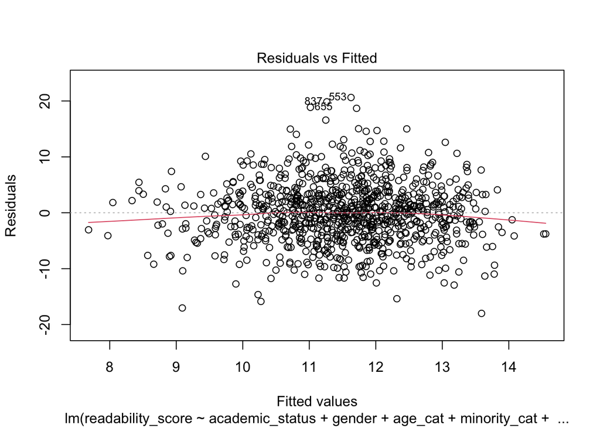

```r
# Plotting residuals vs. fitted values
plot(model_readability, which = 1)
```

*Q-Q Plots for Normality of Residuals*

Q-Q (quantile-quantile) plot to assess whether the residuals follow a normal distribution

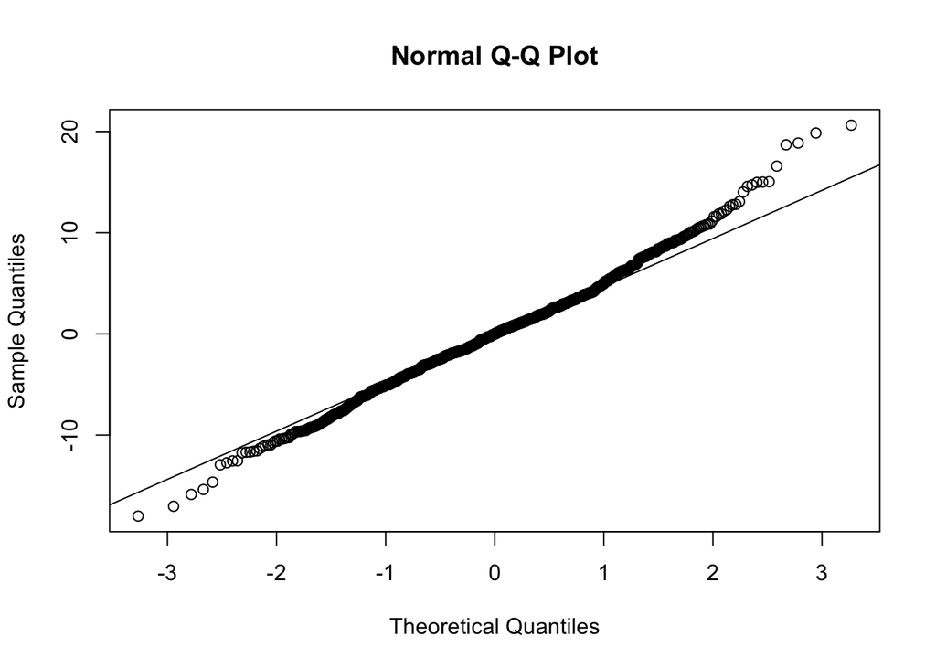

```r
# Q-Q plot
qqnorm(residuals(model_readability))
qqline(residuals(model_readability))
```

*Variance Inflation Factor (VIF) for Multicollinearity*

Assesses how much the variance of a coefficient is inflated due to multicollinearity in the model. VIF values above 5 or 10 indicate high multicollinearity that could be problematic.

```r
library(car)

vif(model_readability)
```

```
##                            GVIF Df GVIF^(1/(2*Df))
## academic_status        1.046606  1        1.023038
## gender                 1.125272  1        1.060788
## age_cat                1.123885  3        1.019656
## minority_cat           1.036120  1        1.017900
## polinterest_cat_3      1.236744  2        1.054557
## empathy_pc             1.063953  1        1.031481
## exp_hate_speech        1.172333  1        1.082743
## exp_hostile_engagement 1.309381  1        1.144282
```

### 2.2.2 Less Controls

```r
# Linear regression model with less controls (assuming that they are later in the causal chain)
model_readability <- lm(readability_score ~ academic_status + gender + age_cat + minority_cat + exp_hate_speech, data = data)

summary(model_readability)
```

```
##
## Call:
## lm(formula = readability_score ~ academic_status + gender + age_cat +
##     minority_cat + exp_hate_speech, data = data)
##
## Residuals:
##      Min       1Q   Median       3Q      Max
## -17.8195  -3.3378  -0.0083   3.1921  21.4778
##
## Coefficients:
##                             Estimate Std. Error t value Pr(>|t|)
## (Intercept)                  9.02824    1.17549   7.680 4.05e-14 ***
## academic_statusnon-academic -0.81721    0.36825  -2.219  0.02672 *
## genderFemale                 0.63869    0.38179   1.673  0.09469 .
## age_cat30-49                 0.11636    0.56229   0.207  0.83610
## age_cat50-69                -0.47395    0.56887  -0.833  0.40498
## age_cat70+                  -1.62845    0.86820  -1.876  0.06102 .
## minority_catMinority        -0.05038    0.38487  -0.131  0.89589
## exp_hate_speech              0.94931    0.34442   2.756  0.00596 **
## ---
## Signif. codes:  0 '***' 0.001 '**' 0.01 '*' 0.05 '.' 0.1 ' ' 1
##
## Residual standard error: 5.463 on 921 degrees of freedom
##   (15 observations deleted due to missingness)
## Multiple R-squared:  0.02667,    Adjusted R-squared:  0.01928
## F-statistic: 3.606 on 7 and 921 DF,  p-value: 0.0007688
```

*Residuals Plot for Homoscedasticity and Linearity*

check if the residuals (differences between observed and predicted values) display constant variance across all levels of the predicted values (homoscedasticity) and if the relationship between the predictors and the outcome is linear.

**Homoscedasticity**: The spread of residuals should be roughly constant across all fitted values.

**Linearity**: The residuals should be randomly dispersed around the horizontal axis, without any systematic shape.

```r
# Plotting residuals vs. fitted values
plot(model_text_length, which = 1)
```

[output not shown]

*Q-Q Plots for Normality of Residuals*

Q-Q (quantile-quantile) plot to assess whether the residuals follow a normal distribution

```r
# Q-Q plot
qqnorm(residuals(model_text_length))
qqline(residuals(model_text_length))
```

[output not shown]

*Variance Inflation Factor (VIF) for Multicollinearity*

Assesses how much the variance of a coefficient is inflated due to multicollinearity in the model. VIF values above 5 or 10 indicate high multicollinearity that could be problematic.

```r
library(car)

vif(model_text_length)
```

```
##                     GVIF Df GVIF^(1/(2*Df))
## academic_status 1.020439  1        1.010168
## gender          1.012136  1        1.006050
## age_cat         1.043753  3        1.007163
## minority_cat    1.021919  1        1.010900
## exp_hate_speech 1.037361  1        1.018509
```

## 2.3 Predictability of Political Orientation

### 2.3.1 More controls

```r
# Linear regression model with all controls
model_leftright_pred_score <- lm(leftright_pred_score ~ academic_status + gender + age_cat + minority_cat + polinterest_cat_3 + empathy_pc + exp_hate_speech + exp_hostile_engagement, data = data)

summary(model_leftright_pred_score)
```

```
##
## Call:
## lm(formula = leftright_pred_score ~ academic_status + gender +
##     age_cat + minority_cat + polinterest_cat_3 + empathy_pc +
##     exp_hate_speech + exp_hostile_engagement, data = data)
##
## Residuals:
##     Min      1Q  Median      3Q     Max
## -4.0559 -0.8406  0.2068  1.1478  2.4965
##
## Coefficients:
##                               Estimate Std. Error t value Pr(>|t|)
## (Intercept)                    8.44360    0.59615  14.164   <2e-16 ***
## academic_statusnon-academic   -0.31462    0.18311  -1.718   0.0869 .
## genderFemale                  -0.17892    0.21207  -0.844   0.3996
## age_cat30-49                   0.64365    0.26740   2.407   0.0168 *
## age_cat50-69                   0.65300    0.27900   2.341   0.0200 *
## age_cat70+                     0.09262    0.42654   0.217   0.8283
## minority_catMinority           0.16274    0.19705   0.826   0.4096
## polinterest_cat_3Intermediate  0.11553    0.27602   0.419   0.6759
## polinterest_cat_3High         -0.16750    0.29235  -0.573   0.5672
## empathy_pc                    -0.04917    0.06853  -0.718   0.4737
## exp_hate_speech               -0.17898    0.17848  -1.003   0.3169
## exp_hostile_engagement        -0.09118    0.15331  -0.595   0.5525
## ---
## Signif. codes:  0 '***' 0.001 '**' 0.01 '*' 0.05 '.' 0.1 ' ' 1
##
## Residual standard error: 1.457 on 262 degrees of freedom
##   (670 observations deleted due to missingness)
## Multiple R-squared:  0.05336,    Adjusted R-squared:  0.01361
## F-statistic: 1.343 on 11 and 262 DF,  p-value: 0.201
```

*Residuals Plot for Homoscedasticity and Linearity*

check if the residuals (differences between observed and predicted values) display constant variance across all levels of the predicted values (homoscedasticity) and if the relationship between the predictors and the outcome is linear.

**Homoscedasticity**: The spread of residuals should be roughly constant across all fitted values.

**Linearity**: The residuals should be randomly dispersed around the horizontal axis, without any systematic shape.

```r
# Plotting residuals vs. fitted values
plot(model_text_length, which = 1)
```

[output not shown]

*Q-Q Plots for Normality of Residuals*

Q-Q (quantile-quantile) plot to assess whether the residuals follow a normal distribution

```r
# Q-Q plot
qqnorm(residuals(model_text_length))
qqline(residuals(model_text_length))
```

[output not shown]

*Variance Inflation Factor (VIF) for Multicollinearity*

Assesses how much the variance of a coefficient is inflated due to multicollinearity in the model. VIF values above 5 or 10 indicate high multicollinearity that could be problematic.

```r
library(car)

vif(model_text_length)
```

```
##                     GVIF Df GVIF^(1/(2*Df))
## academic_status 1.020439  1        1.010168
## gender          1.012136  1        1.006050
## age_cat         1.043753  3        1.007163
## minority_cat    1.021919  1        1.010900
## exp_hate_speech 1.037361  1        1.018509
```

### 2.3.2 Less Controls

```r
# Linear regression model with less controls (assuming that they are later in the causal chain)
model_leftright_pred_score <- lm(leftright_pred_score ~ academic_status + gender + age_cat + minority_cat + exp_hate_speech, data = data)

summary(model_leftright_pred_score)
```

```
##
## Call:
## lm(formula = leftright_pred_score ~ academic_status + gender +
##     age_cat + minority_cat + exp_hate_speech, data = data)
##
## Residuals:
##     Min      1Q  Median      3Q     Max
## -4.0039 -0.9279  0.1872  1.2248  2.3984
##
## Coefficients:
##                             Estimate Std. Error t value Pr(>|t|)
## (Intercept)                  8.12257    0.54711  14.846   <2e-16 ***
## academic_statusnon-academic -0.28375    0.18088  -1.569   0.1179
## genderFemale                -0.10775    0.19997  -0.539   0.5905
## age_cat30-49                 0.60006    0.26160   2.294   0.0226 *
## age_cat50-69                 0.60064    0.26608   2.257   0.0248 *
## age_cat70+                   0.03504    0.41074   0.085   0.9321
## minority_catMinority         0.12211    0.19080   0.640   0.5227
## exp_hate_speech             -0.15097    0.16221  -0.931   0.3528
## ---
## Signif. codes:  0 '***' 0.001 '**' 0.01 '*' 0.05 '.' 0.1 ' ' 1
##
## Residual standard error: 1.461 on 267 degrees of freedom
##   (669 observations deleted due to missingness)
## Multiple R-squared:  0.03797,    Adjusted R-squared:  0.01275
## F-statistic: 1.506 on 7 and 267 DF,  p-value: 0.1653
```

*Residuals Plot for Homoscedasticity and Linearity*

check if the residuals (differences between observed and predicted values) display constant variance across all levels of the predicted values (homoscedasticity) and if the relationship between the predictors and the outcome is linear.

**Homoscedasticity**: The spread of residuals should be roughly constant across all fitted values.

**Linearity**: The residuals should be randomly dispersed around the horizontal axis, without any systematic shape.

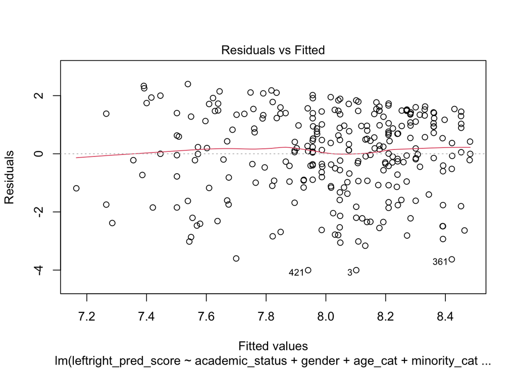

```r
# Plotting residuals vs. fitted values
plot(model_leftright_pred_score, which = 1)
```

*Q-Q Plots for Normality of Residuals*

Q-Q (quantile-quantile) plot to assess whether the residuals follow a normal distribution

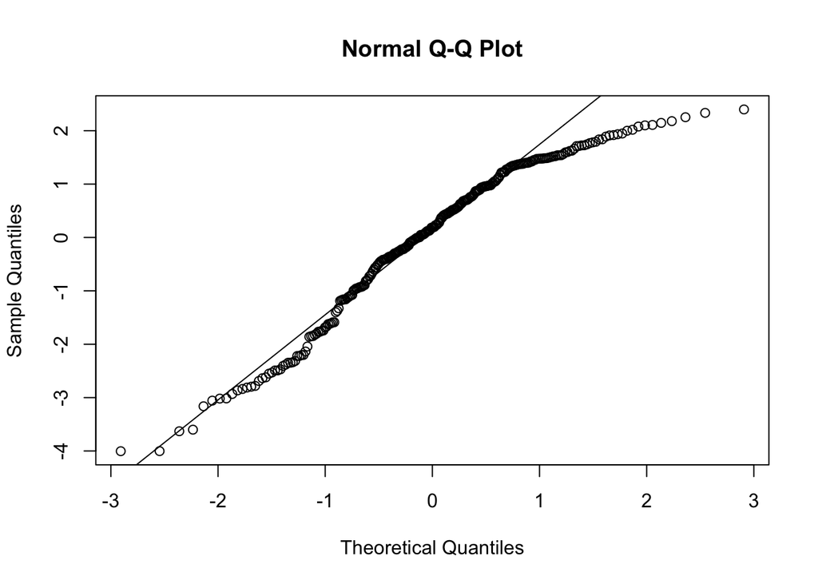

```r
# Q-Q plot
qqnorm(residuals(model_leftright_pred_score))
qqline(residuals(model_leftright_pred_score))
```

*Variance Inflation Factor (VIF) for Multicollinearity*

Assesses how much the variance of a coefficient is inflated due to multicollinearity in the model. VIF values above 5 or 10 indicate high multicollinearity that could be problematic.

```r
library(car)

vif(model_leftright_pred_score)
```

```
##                     GVIF Df GVIF^(1/(2*Df))
## academic_status 1.038846  1        1.019238
## gender          1.047067  1        1.023263
## age_cat         1.063263  3        1.010276
## minority_cat    1.014647  1        1.007297
## exp_hate_speech 1.033288  1        1.016508
```

## 2.4 Cluster (multinomial logistic regression)

### 2.4.1

```r
library(nnet)

# Fit multinomial logistic regression model
model_cluster <- multinom(cluster ~ academic_status + gender + age_cat + minority_cat + polinterest_cat_3 + empathy_pc + exp_hate_speech + exp_hostile_engagement, data = data)
summary(model_cluster)
```

```
## Call:
## multinom(formula = cluster ~ academic_status + gender + age_cat +
##     minority_cat + polinterest_cat_3 + empathy_pc + exp_hate_speech +
##     exp_hostile_engagement, data = data)
##
## Coefficients:
##   (Intercept) academic_statusnon-academic genderFemale age_cat30-49
## B    1.307611                -0.015533975  -0.42302229  -0.16372165
## C    1.290326                 0.344351515  -0.71018040   0.30998361
## D   -0.113190                 0.001675841  -0.07093168   0.01398319
##   age_cat50-69 age_cat70+ minority_catMinority polinterest_cat_3Intermediate
## B   -0.4747968  0.2335910          -0.17138392                    -0.2581839
## C    0.3907920  0.6136771           0.28655512                    -1.0369952
## D   -0.1939393 -0.1975987          -0.09246525                    -0.3926155
##   polinterest_cat_3High  empathy_pc exp_hate_speech exp_hostile_engagement
## B           -0.24364473 -0.06680035      -0.2613621             0.09909719
## C           -0.39194097  0.06035592      -0.7684920             0.31315850
## D           -0.05927058 -0.14303237      -0.1441237             0.19492731
##
## Std. Errors:
##   (Intercept) academic_statusnon-academic genderFemale age_cat30-49
## B   0.6106162                   0.1773752    0.1870989    0.2592728
## C   0.7239712                   0.2055332    0.2369233    0.3474196
## D   0.7037031                   0.2019066    0.2096960    0.3032355
##   age_cat50-69 age_cat70+ minority_catMinority polinterest_cat_3Intermediate
## B    0.2676620  0.4210962            0.1847203                     0.2677642
## C    0.3483339  0.5142331            0.2122989                     0.3184553
## D    0.3117303  0.5318431            0.2090845                     0.3078104
##   polinterest_cat_3High empathy_pc exp_hate_speech exp_hostile_engagement
## B             0.2860090 0.06791964       0.1775929              0.1455313
## C             0.3226051 0.07799899       0.2078525              0.1737411
## D             0.3219545 0.08070957       0.2037487              0.1668539
##
## Residual Deviance: 2428.237
## AIC: 2500.237
```

### 2.4.2 Less controls

```r
# Fit multinomial logistic regression model
model_cluster <- multinom(cluster ~ academic_status + gender + age_cat + minority_cat + exp_hate_speech, data = data)
summary(model_cluster)
```

```
## Call:
## multinom(formula = cluster ~ academic_status + gender + age_cat +
##     minority_cat + exp_hate_speech, data = data)
##
## Coefficients:
##   (Intercept) academic_statusnon-academic genderFemale age_cat30-49
## B   1.2522886                 -0.01119465   -0.4042362  -0.14785224
## C   1.0395726                  0.36124111   -0.8121432   0.25494391
## D  -0.3024212                 -0.01433142   -0.1195076   0.04968208
##   age_cat50-69 age_cat70+ minority_catMinority exp_hate_speech
## B   -0.5034731  0.2439371          -0.15714101    -0.239719587
## C    0.3382787  0.6084177           0.34923805    -0.606209540
## D   -0.1658601 -0.1346666          -0.08400574     0.006548728
##
## Std. Errors:
##   (Intercept) academic_statusnon-academic genderFemale age_cat30-49
## B   0.5583952                   0.1745918    0.1773728    0.2577899
## C   0.6547181                   0.2001978    0.2211836    0.3399358
## D   0.6498613                   0.1984943    0.1979457    0.3007434
##   age_cat50-69 age_cat70+ minority_catMinority exp_hate_speech
## B    0.2627117  0.4112556            0.1830808       0.1638864
## C    0.3366556  0.5008687            0.2078244       0.1904221
## D    0.3046832  0.5228235            0.2066931       0.1885146
##
## Residual Deviance: 2467.245
## AIC: 2515.245
```

These coefficients represent the log odds of being in each category of the outcome variable, compared to the reference category, for a one-unit increase in the predictor variable.

Convert coefficients (log-odds units) to odds ratios for easier interpretation:

```r
# convert coefficients (log-odds units) to odds ratios for easier interpretation
exp(coef(model_cluster))
```

```
##   (Intercept) academic_statusnon-academic genderFemale age_cat30-49
## B   3.4983400                   0.9888678    0.6674864    0.8625586
## C   2.8280080                   1.4351094    0.4439057    1.2903892
## D   0.7390267                   0.9857708    0.8873572    1.0509369
##   age_cat50-69 age_cat70+ minority_catMinority exp_hate_speech
## B    0.6044278  1.2762641            0.8545835       0.7868485
## C    1.4025314  1.8375216            1.4179867       0.5454143
## D    0.8471647  0.8740072            0.9194260       1.0065702
```

An odds ratio greater than 1 indicates an increased likelihood of being in the category compared to the reference category, for a one-unit increase in the predictor variable.

### 2.4.3 Validation

**McFadden’s R-squared**

McFadden’s R-squared is defined as 1 minus the ratio of the log-likelihood of the model over the log-likelihood of the null model (a model with no predictors except the intercept). It gives an indication of the improvement in fit that the model provides over the null model.

```r
# Calculate the log-likelihood of the model
logLik_model <- logLik(model_cluster)

# Fit a null model (with only the intercept)
null_model <- multinom(cluster ~ 1, data = data)
# Calculate the log-likelihood of the null model
logLik_null <- logLik(null_model)

# Calculate McFadden's R-squared
mcfadden_r_squared <- 1 - (as.numeric(logLik_model) / as.numeric(logLik_null))

# Print McFadden's R-squared
print(mcfadden_r_squared)
```

```
## [1] 0.03778865
```

*Interpretation*

A value closer to 0 indicates that the model does not improve much upon the null model. Values closer to 1 suggest that the model provides a significant improvement over the null model. McFadden suggested that a value of 0.2 to 0.4 represents a good fit.

**Confusion Matrix and Classification Accuracy**

The confusion matrix compares the actual vs. predicted classifications and is a powerful tool for understanding model performance across different categories.

```r
library(caret)
# Filtering to complete cases, assuming 'df' is your dataset
data_complete <- data[complete.cases(data), ]

# Refit the model with the complete cases (if not already done)
model_cluster_complete <- multinom(cluster ~ academic_status + gender + age_cat + minority_cat + exp_hate_speech, data = data_complete)
# Generate new predictions
predicted_values_complete <- predict(model_cluster_complete, type="class")

# Now try the confusion matrix again
confusionMatrix(data = predicted_values_complete, reference = data_complete$cluster)
```

```
## Confusion Matrix and Statistics
##
##           Reference
## Prediction  A  B  C  D
##          A 47 26 19 25
##          B 21 39 21 15
##          C  9 13 18  4
##          D  5  2  2  8
##
## Overall Statistics
##
##                Accuracy : 0.4088
##                  95% CI : (0.35, 0.4695)
##     No Information Rate : 0.2993
##     P-Value [Acc > NIR] : 7.509e-05
##
##                   Kappa : 0.1822
##
##  Mcnemar's Test P-Value : 4.059e-05
##
## Statistics by Class:
##
##                      Class: A Class: B Class: C Class: D
## Sensitivity            0.5732   0.4875  0.30000  0.15385
## Specificity            0.6354   0.7062  0.87850  0.95946
## Pos Pred Value         0.4017   0.4062  0.40909  0.47059
## Neg Pred Value         0.7771   0.7697  0.81739  0.82879
## Prevalence             0.2993   0.2920  0.21898  0.18978
## Detection Rate         0.1715   0.1423  0.06569  0.02920
## Detection Prevalence   0.4270   0.3504  0.16058  0.06204
## Balanced Accuracy      0.6043   0.5968  0.58925  0.55665
```